# Parameterising data generating model

## Objective

A data generating model that will

- give rise to polygenic genetic effects on fitness (latent liability scale)
- which lead to an expected distribution of number of children
- whether generated from a Poisson sampling process or by allocating children to parents using the `sample` procedure
- and where the genetic effects estimated on the observed data scale can be translated back to the effects simulated for fitness

Note that absolute genetic variance needs to be specified as this relates to the selection coefficient (not heritability, which is agnostif of scale).

## Models

This model defines the liability

$$l = \mu + Xb + e$$

where $X$ is the centred matrix of genotypes, $\mu$ is the mean fitness on the liability scale in the population, $b$ is the a vector of genetic effects on fitness, also selection coefficients for alleles, $e$ is an overdispersion parameter.

$$h^2_l = \frac{\sum^M_j 2p_j(1-p_j)b_j^2}{\sigma^2_e}$$
and

$$V_{P,l} = \sum^M_j 2p_j(1-p_j)b_j^2 + \sigma^2_e = \sigma^2_a + \sigma^2_e$$

The expected data scale is

$$\nu = exp(l)$$

and the observed data scale, number of children, is

$$z = Pois(\nu)$$

The mean and variance of $z$ are expected to be the same ($\lambda$).

Should be able to calculate the mean and variance of $l$ by

$$\lambda = exp(\mu + V_{P,l}/2)$$

So let’s see if that works

```r
param <- expand.grid(
  lambda = seq(0.1, 3, by=0.1),
  mu = seq(-1, 1, by=0.1)
)
param$vp <- 2 * (log(param$lambda) - param$mu)
param <- subset(param, vp > 0 & vp < 0.4)
dim(param)
```

```
[1] 53  3
```

```r
summary(param)
```

```
     lambda            mu                vp
 Min.   :0.400   Min.   :-1.0000   Min.   :0.01093
 1st Qu.:1.100   1st Qu.:-0.1000   1st Qu.:0.14001
 Median :1.700   Median : 0.4000   Median :0.20000
 Mean   :1.725   Mean   : 0.3094   Mean   :0.22301
 3rd Qu.:2.400   3rd Qu.: 0.8000   3rd Qu.:0.32942
 Max.   :3.000   Max.   : 1.0000   Max.   :0.40000
```

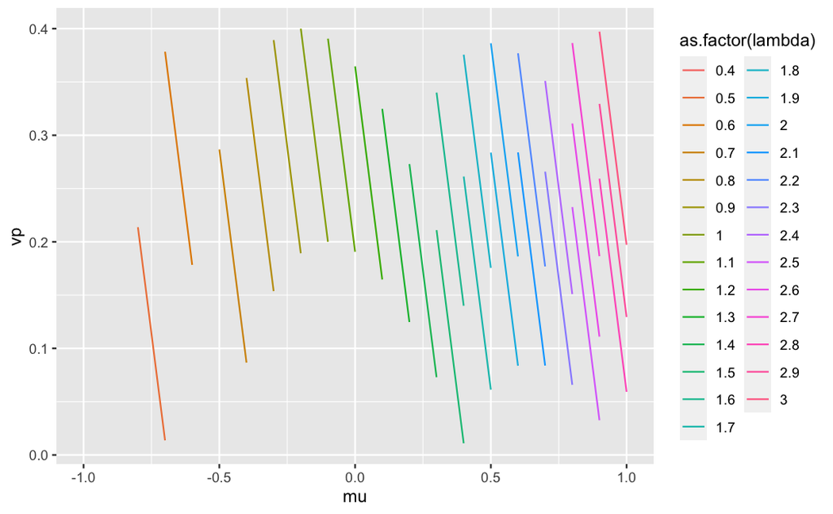

```r
ggplot(param, aes(x=mu, y=vp, group=lambda)) +
  geom_line(aes(colour=as.factor(lambda)))
```

Each line should continue beyond what is plotted however this just shows the parameter ranges that were selected for analysis.

```r
data_generating_model <- function(nid, lambda, mu, vp)
{
  dat <- tibble(
    l = rnorm(nid, mu, sqrt(vp)),
    nu = exp(l),
    z1 = rpois(nid, nu),
    z2 = 0
  )
  tab <- table(sample(1:nid, lambda*nid, replace=TRUE, prob=dat$nu))
  dat$z2[as.numeric(unlist(dimnames(tab)))] <- tab

  tibble(
    lambda=lambda,
    mu=mu,
    vp=vp,
    z1_mean = mean(dat$z1),
    z1_var = var(dat$z1),
    nu_mean = mean(dat$nu),
    nu_var = var(dat$nu),
    z2_mean = mean(dat$z2),
    z2_var = var(dat$z2)
  )
}
```

Example run (where lambda, va and mu were selected randomly and don’t actually adhere to the rule above)

| lambda | mu | vp | z1_mean | z1_var | nu_mean | nu_var | z2_mean | z2_var |
| --- | --- | --- | --- | --- | --- | --- | --- | --- |
| 2 | 0.7 | 0.1 | 2.1271 | 2.559602 | 2.115508 | 0.4723203 | 2 | 2.417842 |

Run simulations

```r
res <- lapply(1:nrow(param), function(i)
{
  data_generating_model(10000, param$lambda[i], param$mu[i], param$vp[i])
}) %>% bind_rows()
res
```

| lambda | mu | vp | z1_mean | z1_var | nu_mean | nu_var | z2_mean | z2_var |
| --- | --- | --- | --- | --- | --- | --- | --- | --- |
| 0.4 | -1.0 | 0.16741854 | 0.4009 | 0.4284220 | 0.4007481 | 0.03005085 | 0.4 | 0.4330433 |
| 0.5 | -0.8 | 0.21370564 | 0.4960 | 0.5620402 | 0.5004567 | 0.05850193 | 0.5 | 0.5636564 |
| 0.5 | -0.7 | 0.01370564 | 0.4858 | 0.4920476 | 0.4995510 | 0.00346732 | 0.5 | 0.5052505 |
| 0.6 | -0.7 | 0.37834875 | 0.5969 | 0.7644868 | 0.6053384 | 0.17309271 | 0.6 | 0.7666767 |
| 0.6 | -0.6 | 0.17834875 | 0.6117 | 0.7073938 | 0.5970241 | 0.07015509 | 0.6 | 0.6924692 |
| 0.7 | -0.5 | 0.28665011 | 0.6977 | 0.8880035 | 0.7025651 | 0.16904590 | 0.7 | 0.8718872 |
| 0.7 | -0.4 | 0.08665011 | 0.6956 | 0.7246131 | 0.6994212 | 0.04489784 | 0.7 | 0.7480748 |
| 0.8 | -0.4 | 0.35371290 | 0.8058 | 1.0743938 | 0.8027584 | 0.27472945 | 0.8 | 1.0755076 |
| 0.8 | -0.3 | 0.15371290 | 0.8022 | 0.9313683 | 0.8023479 | 0.10750077 | 0.8 | 0.8920892 |
| 0.9 | -0.3 | 0.38927897 | 0.8879 | 1.2706607 | 0.8970217 | 0.38677759 | 0.9 | 1.2819282 |

[output cut: 43 more lines]

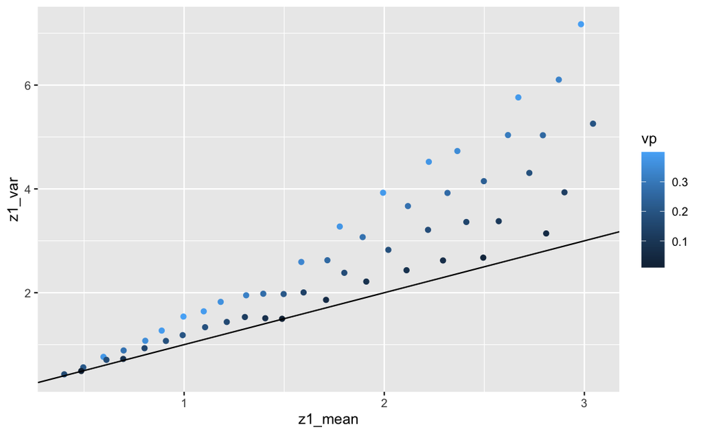

```r
ggplot(res, aes(x=z1_mean, y=z1_var)) +
  geom_point(aes(colour=vp)) +
  geom_abline(slope=1, intercept=0)
```

Ok so when the variance of the liability is 0 then the mean = variance. This is because every individual has the same fitness, and therefore everyone’s number of children is drawn from the same parameter i.e. it’s a single poisson distribution. When fitness varies then everyone has a different lambda value, and while the mean lambda value stays the same the variance of the mixture of poissons is larger than then expected variance for a single poisson.

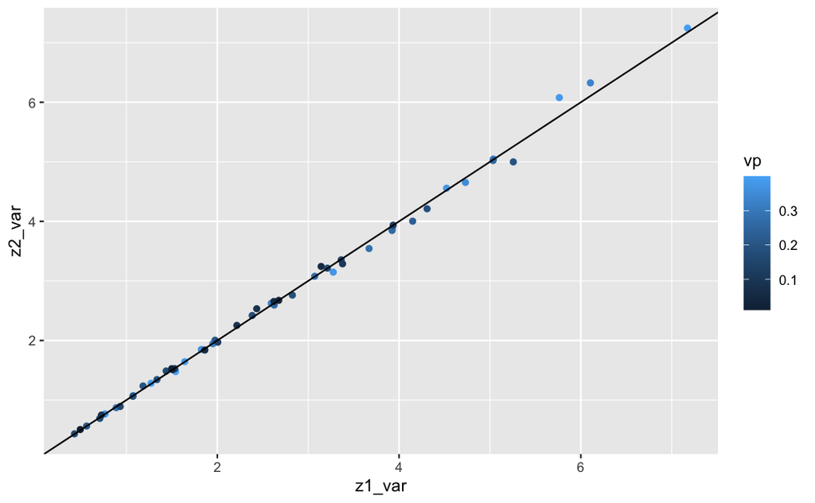

```r
ggplot(res, aes(x=z1_var, z2_var)) +
  geom_point(aes(colour=vp)) +
  geom_abline(slope=1, intercept=0)
```

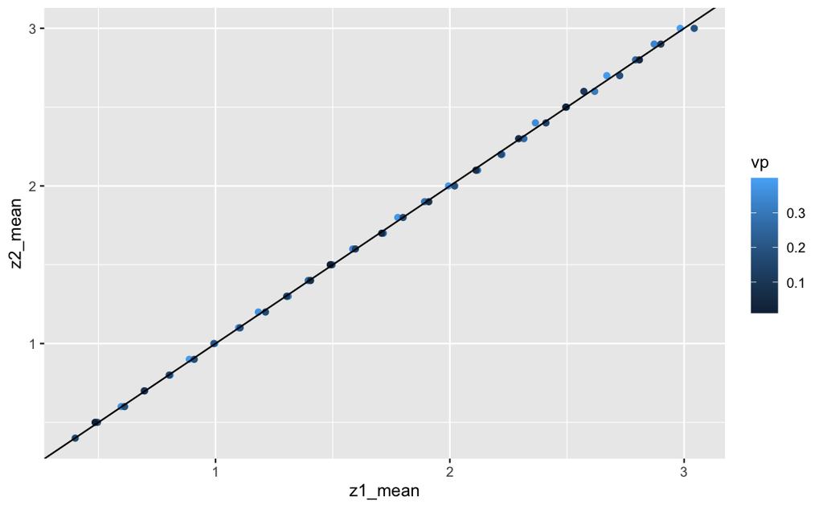

```r
ggplot(res, aes(x=z1_mean, z2_mean)) +
  geom_point(aes(colour=vp)) +
  geom_abline(slope=1, intercept=0)
```

The sample vs poisson methods are basically identical now

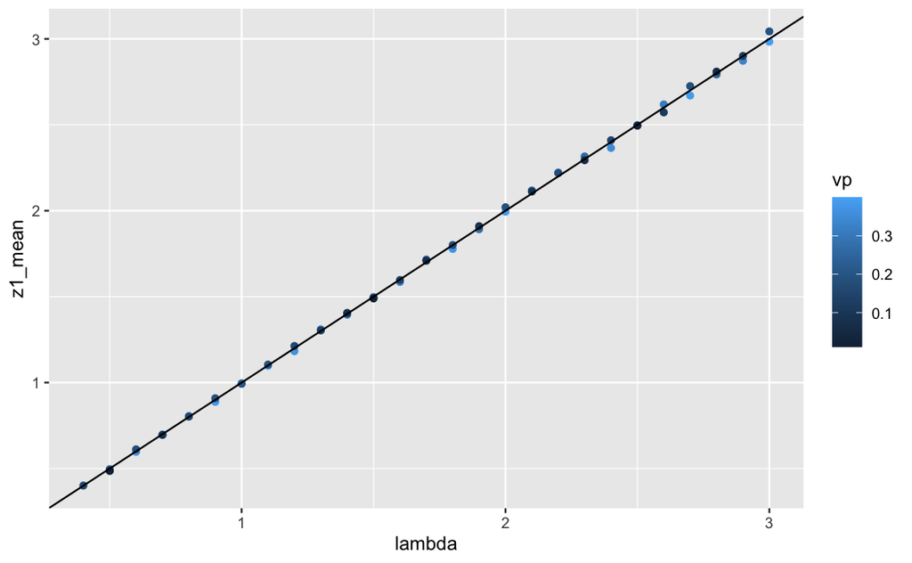

```r
ggplot(res, aes(x=lambda, y=z1_mean)) +
  geom_point(aes(colour=vp)) +
  geom_abline(slope=1, intercept=0)
```

What about the variance of the expected data scale of a log normal distribution (after exponentiating the normal liability scale to get the expected data scale)

$$E[exp(X)] = exp(\mu + \sigma^2/2)$$
and

$$Var[exp(X)] = (exp(\sigma^2) - 1)exp(2\mu + \sigma^2)$$

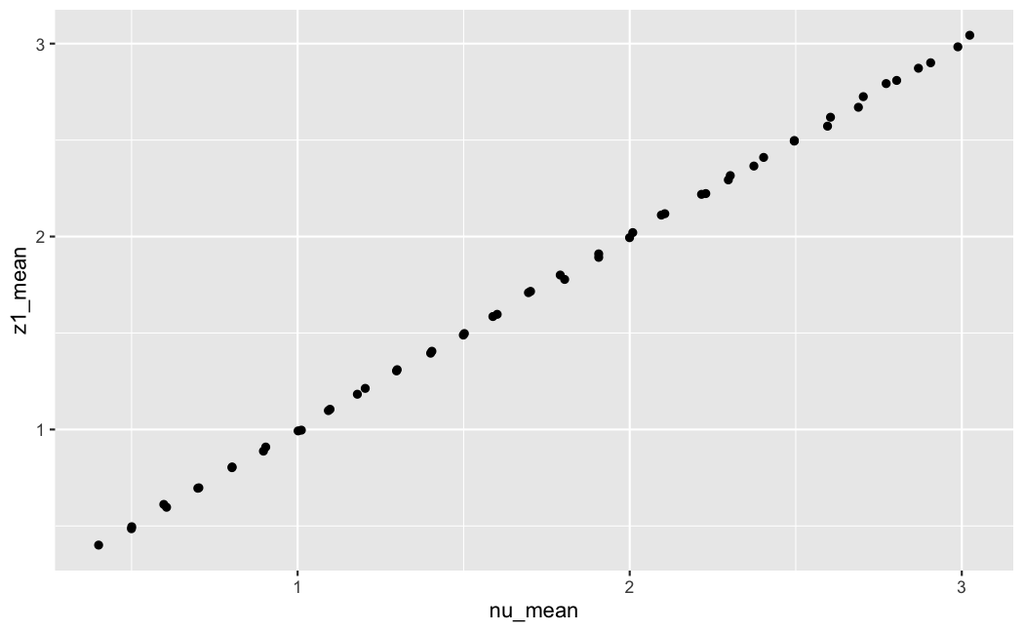

```r
ggplot(res, aes(x=nu_mean, y=z1_mean)) +
  geom_point()
```

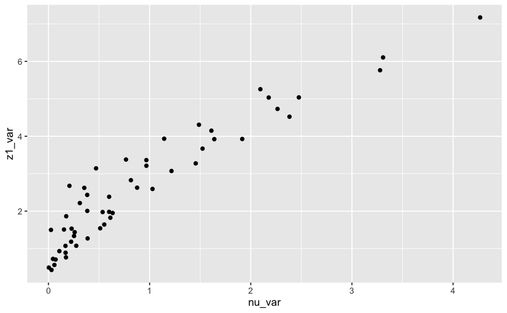

```r
ggplot(res, aes(x=nu_var, y=z1_var)) +
  geom_point()
```

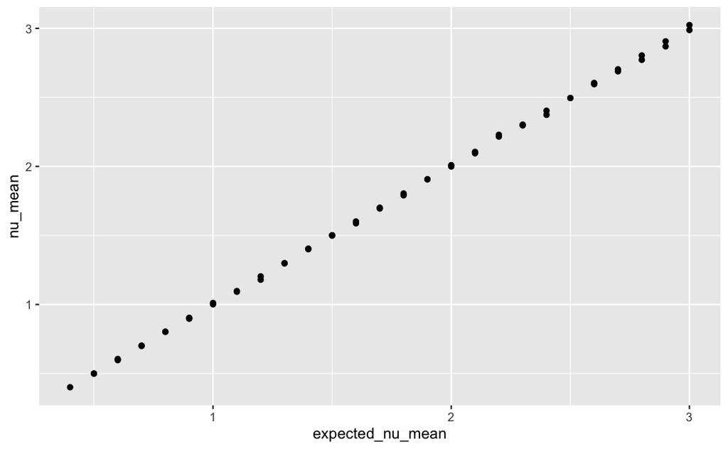

```r
res$expected_nu_mean <- exp(res$mu + res$vp/2)
ggplot(res, aes(x=expected_nu_mean, y=nu_mean)) +
  geom_point()
```

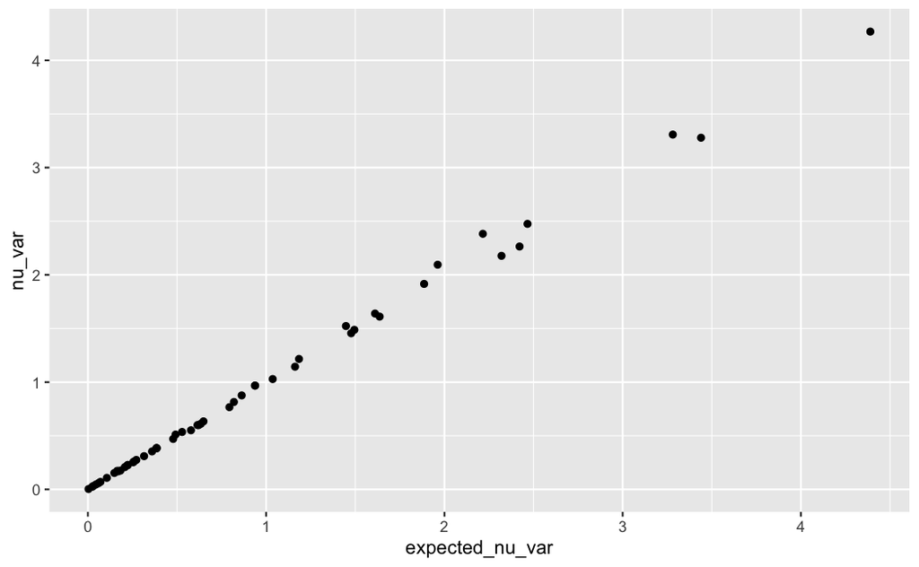

```r
res$expected_nu_var <- (exp(res$vp)-1)*exp(2*res$mu+res$vp)
ggplot(res, aes(x=expected_nu_var, y=nu_var)) +
  geom_point()
```

The expected data scale and liability scales translate as expected.

## The genetic model

The liability is a distribution that is comprised of genetic factors and some overdispersion variance. So total genetic variance is

$$V_A = \sum^M_j 2p_j(1-p_j)\beta^2$$

How should the $\beta$ values be sampled?

$$\beta_j \sim N\left(0, \sigma^2_b \left(\frac{2p_j(1-p_j)}{M} \right)^{S/2} \right)$$

Need to choose some arbitrary value $\sigma^2_b$ that will lead to desired $V_A$.

## Simulation example

Let’s simulate some genetic effects for fitness using a polygenic model as above, that gives rise to a specified Va. Then estimate the effects using a linear model on the number of children (where number of children is sampled using poisson or sample methods).

```r
genetic_model <- function(nid, nsnp, va, ve, mu, lambda)
{
  stopifnot(lambda == exp(mu + (va+ve)/2))
  af <- runif(nsnp, 0.01, 0.99)
  g <- do.call(cbind, lapply(af, function(p) rbinom(nid, 2, p)))
  g <- t(t(g) - colMeans(g))

  b <- rnorm(nsnp, 0, (2*af*(1-af))^(va/2))
  x <- sqrt(sum(2 * af * (1-af) * (b)^2))
  b <- b * sqrt(va)/x
  sum(2 * af * (1-af) * (b)^2)

  dat <- tibble(
    gbv = drop(g %*% b),
    e = rnorm(nid, 0, sqrt(ve)),
    l = mu + gbv + e,
    nu = exp(l),
    z1 = rpois(nid, nu),
    z2 = 0
  )
  tab <- table(sample(1:nid, lambda*nid, replace=TRUE, prob=dat$nu))
  dat$z2[as.numeric(unlist(dimnames(tab)))] <- tab

  res1 <- simulateGP::gwas(dat$z1, g)
  res2 <- simulateGP::gwas(dat$z2, g)
  tibble(
    lambda=lambda,
    mu=mu,
    vp=vp,
    va=va,
    ve=ve,
    nid=nid,
    nsnp=nsnp,
    z1_mean = mean(dat$z1),
    z1_var = var(dat$z1),
    nu_mean = mean(dat$nu),
    nu_var = var(dat$nu),
    z2_mean = mean(dat$z2),
    z2_var = var(dat$z2),
    bhat1=lm(res1$bhat ~ b)$coef[2]/lambda,
    bhat2=lm(res2$bhat ~ b)$coef[2]/lambda
  )
}
```

Set parameters e.g. vary heritability, mu, lambda, va

```r
param <- expand.grid(
  nid = 50000,
  nsnp = c(1, 2, 3, 4, 5, 10, 50, 100, 500),
  ve = c(0, 0.15),
  mu = seq(-1, 1, by=0.3),
  lambda = seq(0.1, 3, by=0.3)
)
param$vp <- 2 * (log(param$lambda) - param$mu)
param$va <- param$vp - param$ve
param <- subset(param, vp > 0 & vp < 0.4 & va > 0)
dim(param)
```

```
[1] 90  7
```

```r
summary(param)
```

```
      nid             nsnp           ve             mu            lambda           vp                va
 Min.   :50000   Min.   :  1   Min.   :0.00   Min.   :-1.00   Min.   :0.40   Min.   :0.08665   Min.   :0.01742
 1st Qu.:50000   1st Qu.:  3   1st Qu.:0.00   1st Qu.:-0.40   1st Qu.:0.70   1st Qu.:0.16742   1st Qu.:0.08258
 Median :50000   Median :  5   Median :0.00   Median : 0.05   Median :1.15   Median :0.20000   Median :0.12922
 Mean   :50000   Mean   : 75   Mean   :0.06   Mean   : 0.02   Mean   :1.36   Mean   :0.19788   Mean   :0.13788
 3rd Qu.:50000   3rd Qu.: 50   3rd Qu.:0.15   3rd Qu.: 0.50   3rd Qu.:1.90   3rd Qu.:0.23258   3rd Qu.:0.20000
 Max.   :50000   Max.   :500   Max.   :0.15   Max.   : 0.80   Max.   :2.50   Max.   :0.28371   Max.   :0.28371
```

Run simulations

```r
str(out)
```

```
tibble[,15] [90 × 15] (S3: tbl_df/tbl/data.frame)
 $ lambda : num [1:90] 0.4 0.4 0.4 0.4 0.4 0.4 0.4 0.4 0.4 0.4 ...
 $ mu     : num [1:90] -1 -1 -1 -1 -1 -1 -1 -1 -1 -1 ...
 $ vp     : num [1:90] 1.19 1.19 1.19 1.19 1.19 ...
 $ va     : num [1:90] 0.167 0.167 0.167 0.167 0.167 ...
 $ ve     : num [1:90] 0 0 0 0 0 0 0 0 0 0.15 ...
 $ nid    : num [1:90] 50000 50000 50000 50000 50000 50000 50000 50000 50000 50000 ...
 $ nsnp   : num [1:90] 1 2 3 4 5 10 50 100 500 1 ...
 $ z1_mean: num [1:90] 0.398 0.411 0.4 0.401 0.403 ...
 $ z1_var : num [1:90] 0.431 0.48 0.428 0.427 0.436 ...
 $ nu_mean: num [1:90] 0.401 0.41 0.4 0.398 0.4 ...
 $ nu_var : num [1:90] 0.03 0.064 0.0287 0.023 0.0293 ...
 $ z2_mean: num [1:90] 0.4 0.4 0.4 0.4 0.4 0.4 0.4 0.4 0.4 0.4 ...
 $ z2_var : num [1:90] 0.43 0.455 0.424 0.422 0.434 ...
 $ bhat1  : Named num [1:90] NA 1.848 1 0.859 1.149 ...
  ..- attr(*, "names")= chr [1:90] "b" "b" "b" "b" ...
 $ bhat2  : Named num [1:90] NA 1.574 0.994 0.848 1.086 ...
  ..- attr(*, "names")= chr [1:90] "b" "b" "b" "b" ...
```

Here `bhat1` is the relationship between estimated genetic effects on fitness, and true effects on fitness, where number of children is generated using `poisson`. And `bhat2` is where number of children is generated using `sample`. We want these values to be 1 - to indicate that we are getting unbiased estimates of fitness effects.

How do the effects compare from sample and poisson

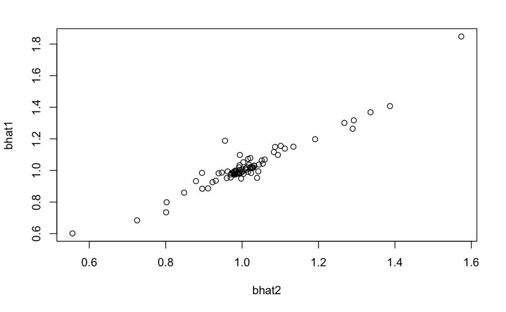

```r
summary(lm(bhat1 ~ bhat2, out))
```

```
Call:
lm(formula = bhat1 ~ bhat2, data = out)

Residuals:
     Min       1Q   Median       3Q      Max
-0.10148 -0.02067 -0.01009  0.00631  0.22681

Coefficients:
            Estimate Std. Error t value Pr(>|t|)
(Intercept) -0.10233    0.04130  -2.478   0.0154 *
bhat2        1.11341    0.04034  27.602   <2e-16 ***
---
Signif. codes:  0 ‘***’ 0.001 ‘**’ 0.01 ‘*’ 0.05 ‘.’ 0.1 ‘ ’ 1

Residual standard error: 0.04747 on 78 degrees of freedom
  (10 observations deleted due to missingness)
Multiple R-squared:  0.9071,    Adjusted R-squared:  0.9059
F-statistic: 761.9 on 1 and 78 DF,  p-value: < 2.2e-16
```

Seems to be good agreement, but sometimes relationship is rather different from 1. Is this because some simulations only have a small number of variants (i.e. is not polygenic)?

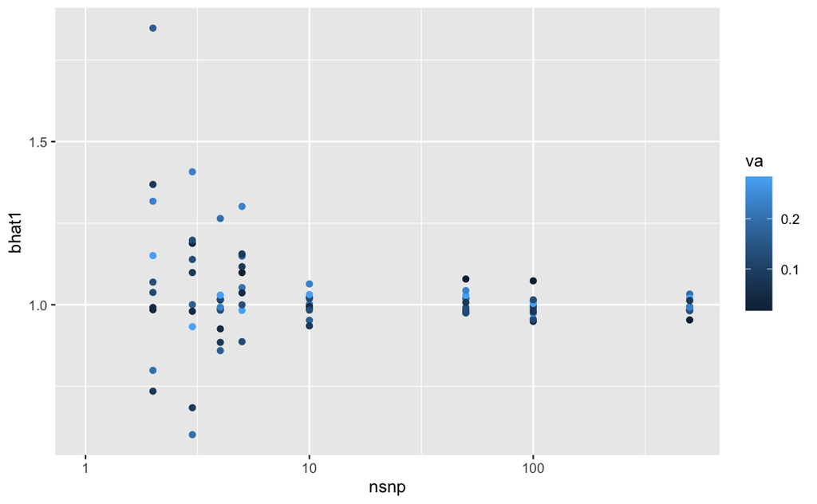

```r
ggplot(out, aes(x=nsnp, y=bhat1)) +
  geom_point(aes(colour=va)) +
  scale_x_log10()
```

Ok so once the number of SNPs is large then the estimates are very close to the simulated values.

## Summary

- Fitness can be normally distributed with some mean and variance
- Variance = additive variance + over dispersion
- Additive variance is equivalent to selection coefficient in breeder’s equation when trait is fitness
- Random noise is introduced when translating from fitness to number of children
- Parameters of fitness distribution can be mapped to parameters of the observed data
- Expect that number of children is not poissonly distributed when variance in fitness is not zero because everyone has a slightly different lambda and the mixture poissons gives rise to larger variance than expected under a single poisson.
- Method using sample and method using poisson will give rise to the same overall process (same distributions of children etc)
- Estimating genetic effects on observed data using a linear model in a polygenic context approximates simulated effects on fitness **provided that beta is divided by the mean number of children** - this has not been done in the recent Nature Human Behaviour paper so the genetic effects on fitness are likely to be 2-3 times over estimated.